# Method 2. Continuous time method to identifying bidirectional effects

Author

Sam Walmsley, Suchinta Arif, Hal Whitehead

This example demonstrates how a model specified with ordinary differential equations can be used to infer bidirectional effects from simulated data. We use the classic lynx-hare predator-prey cycling as the case study for our simulation. This example is adapted from similar studies in McElreath (2020); Park and Bolker (2022); Stan Development Team and Carpenter (2018).

We begin by loading in key packages.

```r
library(deSolve)
library(dagitty)
library(ggdag)
library(fitode)
library(ggplot2)
library(patchwork)
library(data.table)
library(ggforce)
```

First we use the model to build a simulated dataset. This allows us to specify key parameters that we can attempt to recover by fitting an explanatory model to the resulting simulated data.

```r
# Define the ODE system
  ode_system <- function(time, state, parameters) {
    with(as.list(c(state, parameters)), {
      dx <- a*X - b*X*Y
      dy <- c*Y*X - d*Y
      return(list(c(dx, dy)))
    })
  }

  # Simulated data (with added noise)
  set.seed(123)
  times <- seq(0, 50, by = 0.1)
  true_parameters <- c(a = 1.1, b = 0.4, c = 0.1, d = 0.4)
  state <- c(X = 1, Y = 1)
  simulated_data <- ode(y = state, times = times, func = ode_system, parms = true_parameters)
  simulated_data <- as.data.frame(simulated_data)  # Ensure data is a data.frame
  simulated_data$X <- simulated_data$X + rnorm(nrow(simulated_data), sd = 1)
  simulated_data$Y <- simulated_data$Y + rnorm(nrow(simulated_data), sd = 1)
```

Here we define the explanatory model.

```r
  lotka_model <- odemodel(
    name="Lotka Volterra model",
    model=list(
      u ~ a * u - b * u * v,
      v ~ c * u * v - d * v
    ),
    observation=list(
      X ~ dpois(lambda=u),
      Y ~ dpois(lambda=v)
    ),
    initial=list(
      u ~ u0,
      v ~ v0
    ),
    par=c("a", "b", "c", "d", "u0", "v0")
  )
```

Next we specify the starting parameters and fit the model using MCMC in the *fitODE* package. Though beyond the scope of this article, we note that the identification of starting parameters can be a significant challenge.

```r
  harestart <- c(a = 0.5,
                 b = 0.5,
                 c = 0.5,
                 d = 0.5,
                 u0 = 1,
                 v0 = 1)


  proposal.vcov <- matrix(0, 6, 6)
  diag(proposal.vcov) <- c(1e-4, 1e-4, 1e-4, 1e-4, 1e-4, 1e-4)

  fitMCMC <- fitodeMCMC(lotka_model, data=simulated_data,
                        start=harestart,
                        proposal.vcov = proposal.vcov,
                        tcol="time")
```

```r
fitMCMC
```

```
Model: Lotka Volterra model

Observations:
X ~ dpois(lambda = u)
Y ~ dpois(lambda = v)

Priors:

None

Coefficients:
        a         b         c         d        u0        v0
0.9333583 0.3561711 0.1260905 0.4915579 1.0871176 0.7175939

Samples: 1 chains, each with iter = 2000; burnin = 1000; thin = 1

link: a = log; b = log; c = log; d = log; u0 = log; v0 = log
```

Finally, we plot the results for comparison.

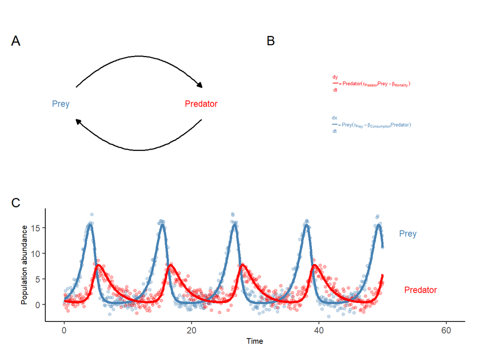

```r
# Set up colors

my_cols <- c('steelblue','red')


# Oversimplified DAG
dag_text <- 'dag{
A -> B;
B -> A;
}'

dag <- dagitty(dag_text)

# Manually set the coordinates of the nodes
coordinates(dag) <- list(
  x = c(A = 1, B = 2),
  y = c(A = 1, B = 1)
)


p1 <- ggdag(dag) +
  geom_dag_node(colour='white') +
  geom_dag_edges(edge_color='white')+
  geom_dag_edges_arc()+
  geom_dag_text(
    label=c('Prey','Predator'),
    parse=FALSE,
    size=c(2,2),
    colour = c('white','white')
  ) +
  annotate('text', x=1, y=1,label='Prey',color=my_cols[1],size=3)+
  annotate('text', x=1.9, y=1,label='Predator',color=my_cols[2],size=3)+
  theme_dag()

pred <- predict(fitMCMC,0.95,simplify=TRUE)
data <- data.table(fitMCMC@data)
dataLong <- melt(data, id.vars='times')

g1 <- ggplot(dataLong, aes(x=times, y=value, group=variable, color=variable))+
  geom_point(alpha=0.3, size=1.25)+
  geom_line(inherit.aes = FALSE, data=pred$X, aes(x=times, y=estimate), alpha=1, linewidth=1.1, color=my_cols[1])+
  geom_line(inherit.aes = FALSE, data=pred$Y, aes(x=times, y=estimate), alpha=1, linewidth=1.1, color=my_cols[2])+
  labs(x='Time', y='Population abundance')+
  annotate('text', x=54, y=14,label='Prey',color=my_cols[1],size=3)+
  annotate('text', x=56, y=3,label='Predator',color=my_cols[2],size=3)+
  theme_classic()+
  scale_color_manual(values=c(my_cols))+
  xlim(0,60)+
  theme(legend.position='none', axis.title=element_text(size=8))


g2 <- ggplot() +
  annotate('text', x=0, y=0.4, label=expression(frac(dy, dt) == Predator(r[Predator]*Prey - beta[Mortality])),size=1.75, col=my_cols[2])+
  annotate('text', x=0, y=-0.4, label=expression(frac(dx, dt) == Prey(r[Prey] - beta[Consumption]*Predator)), size=1.75, col=my_cols[1])+
  ylim(-1,1)+
  xlim(-10,10)+
  theme_no_axes()+
  theme(panel.border = element_blank(),
        plot.margin = unit(c(1,1,1,1), "cm"))

((p1 | g2) / g1) + plot_annotation(tag_levels='A')
```

## References

McElreath, Richard. 2020. *Statistical Rethinking2: A Bayesian Course with Examples in R and Stan*. Boca Raton, Florida: CRC Press.

Park, Sang Woo, and Ben Bolker. 2022. “Fitode: Tools for Ordinary Differential Equations Model Fitting.” R.

Stan Development Team, and Bob Carpenter. 2018. “Stan Modeling Language: Users Guide and Reference Manual.” Predator-Prey Population Dynamics: The Lotka-Volterra Model in Stan. https://mc-stan.org/users/documentation/case-studies/lotka-volterra-predator-prey.html.